# ADP06

#### 텍스트 마이닝

- 감성분석, 워드 클라우드
- 이 정보를 클러스터링, 분류, SNA분석에 활용

##### 데이터 전처리

- Corpus : 데이터마이닝의 절차 중 정제, 통합, 선택, 변환의 과정을 거친 구조화된 단계, 더이상 추가적인 절차 없이 데이터마이닝 알고리즘 실험에 활용될 수 있는 상태
- VCorpus : 문서를 Corpus class로 만들어주는 함수, R메모리에서만 유지

```r
library(tm)
```

```r
data(crude)
summary(crude)[1:6,]
```

```
##     Length Class             Mode
## 127 2      PlainTextDocument list
## 144 2      PlainTextDocument list
## 191 2      PlainTextDocument list
## 194 2      PlainTextDocument list
## 211 2      PlainTextDocument list
## 236 2      PlainTextDocument list
```

- 문서의 글자 수 확인

```r
inspect(crude[1])
```

```
## <<VCorpus>>
## Metadata:  corpus specific: 0, document level (indexed): 0
## Content:  documents: 1
##
## $`reut-00001.xml`
## <<PlainTextDocument>>
## Metadata:  15
## Content:  chars: 527
```

```r
crude[[1]]$content
```

```
## [1] "Diamond Shamrock Corp said that\neffective today it had cut its contract prices for crude oil by\n1.50 dlrs a barrel.\n    The reduction brings its posted price for West Texas\nIntermediate to 16.00 dlrs a barrel, the copany said.\n    \"The price reduction today was made in the light of fal…
```

##### 텍스트 데이터를 문서로

VectorSource(text)

##### 문서로 완성된 데이터를 Corpus로

VCorpus(data)

##### 데이터 전처리

- Corpus로 변환된 데이터를 tm_map 함수를 활용하여 텍스트 전처리 수행

tm_map(x, FUN, …) - FUN : (tolower : 소문자 / stemDocument : 어근만 남기기 / stripWhitespace : 공백 제거 / removePunctuation : 문장부호 제거 / removeNumbers : 숫자 제거 / removeWords, “word” : “word”라는 단어 제거 / removeWords, stopwords(“english”) : 불용어 제거 / PlainTextdocument : TextDocument로 변환)

```r
news <- readLines("C:/Users/이찬솔/Desktop/숭실/R/ADP/PART 06 실습용 데이터/키워드_뉴스.txt")
```

```r
news.corpus <- VCorpus(VectorSource(news))
news.corpus[[1]]$content
```

```
## [1] "동아대학교(총장 한석정)가 '수요자 데이터기반 스마트헬스케어 서비스'분야 ‘4차 산업혁명 혁신선도대학으로 최종선정됐습니다. 동아대가 혁신선도대학으로 펼치게 될 ‘수요자 데이터기반 스마트헬스케어 서비스’ 산업은 리빙데이터(운동·영양·약물)와 메디컬데이터(생체계측·진료기록)를 종합 분석, 다양한 헬스케어 서비스를 제공하는 것입니다. 동아대는 건강과학대학과 의료원, 재활요양병원 등 경쟁력 있는 인프라를 바탕으로 신뢰도 높은 정밀 분석을 실시, ‘헬스케어 기획 전문가’와 ‘헬스케어 데이터분석 전문가’ 등 수요자 맞춤형 헬스케…
```

- 데이터 전처리 (숫자제거, 문장부호 제거, 공백 제거)

```r
clean_txt <- function(txt) {
  txt <- tm_map(txt, removeNumbers)
  txt <- tm_map(txt, removePunctuation)
  txt <- tm_map(txt, stripWhitespace)
  return(txt)
}
clean.news <- clean_txt(news.corpus)
clean.news[[1]]$content
```

```
## [1] "동아대학교총장 한석정가 수요자 데이터기반 스마트헬스케어 서비스분야 ‘차 산업혁명 혁신선도대학으로 최종선정됐습니다 동아대가 혁신선도대학으로 펼치게 될 ‘수요자 데이터기반 스마트헬스케어 서비스’ 산업은 리빙데이터운동·영양·약물와 메디컬데이터생체계측·진료기록를 종합 분석 다양한 헬스케어 서비스를 제공하는 것입니다 동아대는 건강과학대학과 의료원 재활요양병원 등 경쟁력 있는 인프라를 바탕으로 신뢰도 높은 정밀 분석을 실시 ‘헬스케어 기획 전문가’와 ‘헬스케어 데이터분석 전문가’ 등 수요자 맞춤형 헬스케어 서비스 분야를 선도하는…
```

- 특수문자 제거

```r
news_pre <- gsub("[\r\n\t]", ' ', news) # 이스케이프 제거
news_pre <- gsub('[[:punct:]]', ' ', news_pre) # 문장부호 제거
news_pre <- gsub('[[:cntrl:]]', ' ', news_pre) # 특수문자 제거
news_pre <- gsub('\\d+', ' ', news_pre)   # 숫자 제거
news_pre <- gsub('[a-z]+', ' ', news_pre) # 영 대문자 제거
news_pre <- gsub('[A-Z]+', ' ', news_pre) # 영 소문자 제거
news_pre <- gsub('\\s+', ' ', news_pre) # 2개 이상 공백 교체
news_pre[[1]]
```

```
## [1] "동아대학교 총장 한석정 가 수요자 데이터기반 스마트헬스케어 서비스 분야 차 산업혁명 혁신선도대학으로 최종선정됐습니다 동아대가 혁신선도대학으로 펼치게 될 수요자 데이터기반 스마트헬스케어 서비스 산업은 리빙데이터 운동 영양 약물 와 메디컬데이터 생체계측 진료기록 를 종합 분석 다양한 헬스케어 서비스를 제공하는 것입니다 동아대는 건강과학대학과 의료원 재활요양병원 등 경쟁력 있는 인프라를 바탕으로 신뢰도 높은 정밀 분석을 실시 헬스케어 기획 전문가 와 헬스케어 데이터분석 전문가 등 수요자 맞춤형 헬스케어 서비스 분야를 선도하…
```

##### 자연어 처리

- 형태소 분석, 문장의 품사만 구분하여 분석에 필요한 품사만 추출

##### KoNLP

- KoNLP가 대표적이며, KoNLP 사용 시 rJava패키지를 설치해야 함
- 자연어 처리에 앞서 reference를 삼을 사전을 설정. 주로 SejongDic 사용,
- extraNoun, mergeUserDic, SimplePos09 등의 함수로 자연어 처리가 가능

##### 사전에 단어 추가

buildDictionary(ext_dic, data) - ext_dic : 단어를 추가하고자 하는 사전을 선택 (“woorimalsam” , “sejong”, “insighter”s) - data : 추가하고자 하는 단어와 품사가 들어간 data.frame 또는 txt파일

useSejongDic()

##### 문장에서 명사만 추출

extraNoun(text)

##### 문장을 형태소로 분리하여 22개의 품사 태그를 달기

SimplePos22(text)

```r
library(KoNLP)
```

```r
useSejongDic()
```

```
## Backup was just finished!
## 370957 words dictionary was built.
```

```r
sentence <- "아버지가 방에 스르륵 들어가신다"
extractNoun(sentence)
```

```
## [1] "아버지" "방"     "스르륵"
```

- “아버지”, “방”은 명사
- “스르륵”은 부사
- sejong사전에 “스르륵”을 부사(mag)로 추가

```r
buildDictionary(ext_dic = "sejong", user_dic = data.frame(c("스르륵"), c("mag")))
```

```
## 370963 words dictionary was built.
```

```r
extractNoun(sentence)
```

```
## [1] "아버지" "방"
```

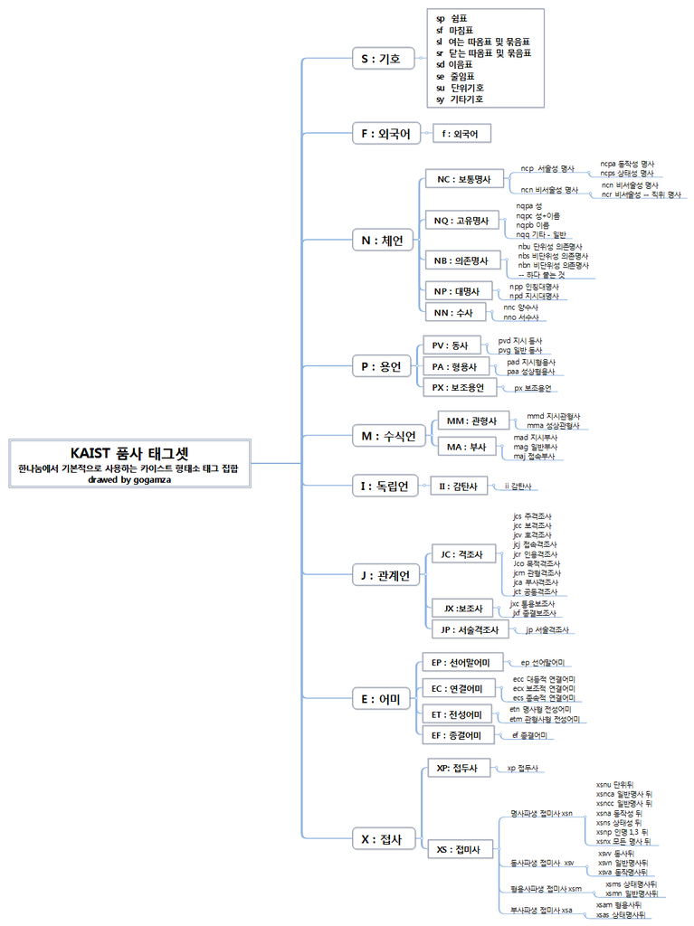

```r
knitr::include_graphics("C:/Users/이찬솔/Desktop/숭실/R/ADP/konlp_tags.png")
```

- S : 기호 (sp : 쉼표 / sf : 마침표 / sl : 여는 따음표 및 묶음표 / sr : 닫는 따음표 및 묶음표 / sd : 이음표 / se : 줄임표 / su : 단위기호 / sy : 기타기호)
- F : 외국어 (f : 외국어)
- N : 체언 (NC : 보통명사 / NQ : 고유명사 / NB : 의존명사 / NP : 대명사 / NN : 수사)
- P : 용언 (PV : 동사 / PA : 형용사 / PX : 보조용언)
- M : 수식언 (MM : 관형사 / MA : 부사)
- I : 독립언 (II : 감탄사)
- J : 관계언 (JC : 격조사 / JX : 보조사 / JP : 서술격조사)
- E : 어미 (EP : 선어말어미 / EC : 연결어미 / ET : 전성어미 / EF : 종결어미)
- X : 접사 (XP : 접두사 / XS : 접미사)

```r
SimplePos22(sentence)
```

```
## $아버지가
## [1] "아버지/NC+가/JC"
##
## $방에
## [1] "방/NC+에/JC"
##
## $스르륵
## [1] "스르륵/MA"
##
## $들어가신
## [1] "들/PV+어/EC+가/PX+시/EP+ㄴ/ET"
##
## $다
## [1] "다/MA"
```

```r
clean_txt2<-function(txt){
  txt <- removeNumbers(txt)  #숫자 제거
  txt <- removePunctuation(txt) #문장부호 제거
  txt <- stripWhitespace(txt) #공백제거
  txt <- gsub("[^[:alnum:]]"," ",txt) #영숫자, 문자를 제외한 것들을 " "으로 처리
  return(txt)
}
```

```r
clean.news2<-clean_txt2(news)
Noun.news <- extractNoun(clean.news2) #각 문서마다 명사가 추출
Noun.news[[5]][1:100]
```

```
##   [1] "푸드테크"       "스타트업"       "들이"           "빅데이터"
##   [5] "기반"           "시스템"         "배달"           "체계"
##   [9] "전환"           "일선"           "상점"           "배달기사"
##  [13] "수익"           "향상"           "초점"           "것"
##  [17] "특징"           "고객"           "입장"           "도착"
##  [21] "시간"           "수"             "배달"           "업체"
##  [25] "경쟁이"         "속도"           "빅데이터"       "양상"
##  [29] "일"             "업계"           "배달"           "스타트업"
##  [33] "들이"           "빅데이터"       "기반"           "배송"
##  [37] "효율화"         "작업"           "속도"           "우아한형제들"
##  [41] "대표"           "김봉진이"       "운영"           "음식"
##  [45] "배달"           "브랜드"         "배민라이더스는" "고객"
##  [49] "편의성"         "빅데이터"       "도입"           "배달"
##  [53] "음식"           "도착"           "예상"           "시간"
##  [57] "주문"           "데이터"         "축적"           "예측"
##  [61] "오차"           "줄"             "배달기사"       "추천"
##  [65] "배차"           "시스템"         "개발"           "실시간"
##  [69] "데이터"         "분석"           "기술"           "적용"
##  [73] "배달기사"       "별"             "맞춤"           "형"
##  [77] "배달"           "주문"           "연결"           "이"
##  [81] "동"             "경로"           "제시"           "배달"
##  [85] "시간"           "줄"             "것"             "배달기사"
##  [89] "경쟁"           "완화"           "우아한형제들"   "지난해"
##  [93] "기준"           "전년"           "대비"           "데이터"
##  [97] "서비스"         "팀"             "인력"           "두"
```

```r
buildDictionary(ext_dic = "sejong", user_dic = data.frame(c(read.table("C:/Users/이찬솔/Desktop/숭실/R/ADP/PART 06 실습용 데이터/food.txt"))))
```

```
## 370967 words dictionary was built.
```

```r
extractNoun(clean.news2[[5]])[1:100]
```

```
##   [1] "푸드테크"       "스타트업"       "들이"           "빅데이터"
##   [5] "기반"           "시스템"         "배달"           "체계"
##   [9] "전환"           "일선"           "상점"           "배달기사"
##  [13] "수익"           "향상"           "초점"           "것"
##  [17] "특징"           "고객"           "입장"           "도착"
##  [21] "시간"           "수"             "배달"           "업체"
##  [25] "경쟁이"         "속도"           "빅데이터"       "양상"
##  [29] "일"             "업계"           "배달"           "스타트업"
##  [33] "들이"           "빅데이터"       "기반"           "배송"
##  [37] "효율화"         "작업"           "속도"           "우아한형제들"
##  [41] "대표"           "김봉진이"       "운영"           "음식"
##  [45] "배달"           "브랜드"         "배민라이더스는" "고객"
##  [49] "편의성"         "빅데이터"       "도입"           "배달"
##  [53] "음식"           "도착"           "예상"           "시간"
##  [57] "주문"           "데이터"         "축적"           "예측"
##  [61] "오차"           "줄"             "배달기사"       "추천"
##  [65] "배차"           "시스템"         "개발"           "실시간"
##  [69] "데이터"         "분석"           "기술"           "적용"
##  [73] "배달기사"       "별"             "맞춤"           "형"
##  [77] "배달"           "주문"           "연결"           "이"
##  [81] "동"             "경로"           "제시"           "배달"
##  [85] "시간"           "줄"             "것"             "배달기사"
##  [89] "경쟁"           "완화"           "우아한형제들"   "지난해"
##  [93] "기준"           "전년"           "대비"           "데이터"
##  [97] "서비스"         "팀"             "인력"           "두"
```

```r
readLines("C:/Users/이찬솔/Desktop/숭실/R/ADP/PART 06 실습용 데이터/food.txt")
```

```
## [1] "푸드테크 ncn"     "스타트업 ncn"     "빅데이터 ncn"     "우아한형제들 ncn"
```

- SimplePos22를 활용해 형용사 추출하기.(stringr 패키지의 str_match함수로 형용사 뽑아내기)

```r
library(stringr)
```

- SimplePos22를 통해 품사를 구분하고, 분석에 용이하게 하기 위해

```r
(doc1 <- paste(SimplePos22(clean.news2[[2]])))[1:100]
```

```
##   [1] "첨단/NC"                     "정보통신기술/NC+에/JC"
##   [3] "AI/F"                        "등/NB+이/JC"
##   [5] "더하/PA+어/EC+지/PX+면서/EC" "무기체계/NC+가/JC"
##   [7] "날/NC+로/JC"                 "지능/NC+화하/XS+는/ET"
##   [9] "가운데/NC"                   "국방개혁/NC"
##  [11] "추진/NC+과/JC"               "차/NC"
##  [13] "산업기술/NC+의/JC"           "군사분야/NC"
##  [15] "접목/NC"                     "속도/NC+가/JC"
##  [17] "빠르/PA+아/EC+지/PX+고/EC"   "있/PX+다/EF"
##  [19] "국방부/NC+가/JC"             "년/NB+까지/JX"
##  [21] "굴/PV+ㄴ/ET"                 "내부/NC+의/JC"
##  [23] "데이터베이스/NC+를/JC"       "기초/NC+로/JC"
##  [25] "전장/NC+의/JC"               "모든/MM"
##  [27] "변수/NC+를/JC"               "모으/PV+아/EC"
##  [29] "최선/NC+의/JC"               "작전계획/NC+을/JC"
```

[output cut: 35 more lines]

- 품사중 PA가 형용사이므로 형용사만 뽑아내기 위해 str_match함수 이용

```r
(doc2<-str_match(doc1,"([가-힣]+)/PA"))[1:100]
```

```
##   [1] NA        NA        NA        NA        "더하/PA" NA        NA
##   [8] NA        NA        NA        NA        NA        NA        NA
##  [15] NA        NA        "빠르/PA" NA        NA        NA        NA
##  [22] NA        NA        NA        NA        NA        NA        NA
##  [29] NA        NA        NA        NA        NA        NA        NA
##  [36] NA        NA        NA        NA        NA        NA        NA
##  [43] NA        NA        NA        NA        NA        NA        NA
##  [50] NA        NA        NA        NA        NA        NA        NA
##  [57] NA        NA        NA        NA        NA        NA        NA
##  [64] NA        NA        NA        NA        NA        NA        NA
##  [71] NA        NA        NA        NA        NA        NA        NA
##  [78] "새롭/PA" NA        NA        NA        NA        NA        NA
##  [85] NA        NA        NA        NA        NA        NA        NA
##  [92] NA        NA        NA        NA        NA        NA        NA
##  [99] NA        NA
```

##### Stemming

- 어간 추출은 정해진 규칙만 보고 단어의 어미를 자르는 어림짐작의 작업
- 즉, 공통 어간을 가지는 단어를 묶는 작업을 Stemming

##### 공통으로 들어가지 않은 부분을 제외

stemDocument(text)

```r
library(SnowballC)
(test <- tm::stemDocument(c('analyze', 'analyzed','analyzing')))
```

```
## [1] "analyz" "analyz" "analyz"
```

##### 가장 기본적인 어휘로 완성

stemCompletion(text, dictionary) - text : stemming이 완료된 문자 - dictionary : 어간 추출이 필요한 단어를 사전에 추가

```r
(completion<-stemCompletion(test,dictionary = c('analyze', 'analyzed','analyzing')))
```

```
##    analyz    analyz    analyz
## "analyze" "analyze" "analyze"
```

#### Term Document Matrix

- 전처리된 데이터에서 각 문서와 단어 간의 사용여부를 이용해 만들어진 matrix
- 문서마다 등장한 단어의 빈도수를 쉽게 파악

TermDocumentMatrix(data, control) - data : Corpus 형태의 데이터 - control : 사전 변경, 가중치 부여 등의 옵션

```r
VC.news <- VCorpus(VectorSource(clean.news2))
VC.news[[1]]$content
```

```
## [1] "동아대학교총장 한석정가 수요자 데이터기반 스마트헬스케어 서비스분야  차 산업혁명 혁신선도대학으로 최종선정됐습니다 동아대가 혁신선도대학으로 펼치게 될  수요자 데이터기반 스마트헬스케어 서비스  산업은 리빙데이터운동 영양 약물와 메디컬데이터생체계측 진료기록를 종합 분석 다양한 헬스케어 서비스를 제공하는 것입니다 동아대는 건강과학대학과 의료원 재활요양병원 등 경쟁력 있는 인프라를 바탕으로 신뢰도 높은 정밀 분석을 실시  헬스케어 기획 전문가 와  헬스케어 데이터분석 전문가  등 수요자 맞춤형 헬스케어 서비스 분야를 선도하는…
```

```r
TDM.news <- TermDocumentMatrix(VC.news)
dim(TDM.news)
```

```
## [1] 1011   10
```

- 10개의 기사에서 1011개의 단어가 추출

```r
inspect(TDM.news[1:5,])
```

```
## <<TermDocumentMatrix (terms: 5, documents: 10)>>
## Non-/sparse entries: 5/45
## Sparsity           : 90%
## Maximal term length: 8
## Weighting          : term frequency (tf)
## Sample             :
##            Docs
## Terms       1 10 2 3 4 5 6 7 8 9
##   academy는 0  0 0 0 1 0 0 0 0 0
##   ai가      0  1 0 0 0 0 0 0 0 0
##   ai를      0  0 0 1 0 0 0 0 0 0
##   ai와      0  1 0 0 0 0 0 0 0 0
##   ai의      0  0 0 0 1 0 0 0 0 0
```

- TDM구축 결과

##### 명사만 추출하는 TermDocumentMatrix를 만들기위한 사용자 정의함수 생성

```r
words <- function(doc){
  doc <- as.character(doc)
  extractNoun(doc)
}
TDM.news2<-TermDocumentMatrix(VC.news, control=list(tokenize=words))
dim(TDM.news2)
```

```
## [1] 289  10
```

- 10개의 기사에서 총 289개의 단어가 추출되어 289개의 행과 10개의 열을 가지는 형태

```r
inspect(TDM.news2)
```

```
## <<TermDocumentMatrix (terms: 289, documents: 10)>>
## Non-/sparse entries: 360/2530
## Sparsity           : 88%
## Maximal term length: 14
## Weighting          : term frequency (tf)
## Sample             :
##             Docs
## Terms        1 10 2 3 4  5  6 7 8 9
##   경쟁력     1  0 0 2 0  1  1 0 1 1
##   경진대회   0  0 0 0 1  0  0 2 0 5
##   관계자     0  1 0 1 0  3  0 1 0 0
##   광양제철소 0  0 0 0 0  0  0 0 0 6
##   데이터     3  6 3 7 8  7 10 3 5 5
##   브라이틱스 0  0 0 0 9  0  0 0 0 0
##   빅데이터   1  4 4 1 3 16  0 2 1 6
##   서비스     3  3 3 0 0  7  3 1 0 0
##   시스템     0  2 0 2 1  3  0 0 0 0
##   전문가     2  1 1 4 1  1  1 1 2 1
```

- 생성된 TDM에서 전체 문서와 단어의 분포를 확인.

```r
tdm2 <- as.matrix(TDM.news2)
tdm3 <- rowSums(tdm2)
tdm4 <- tdm3[order(tdm3, decreasing = T)]
tdm4[1:10]
```

```
##     데이터   빅데이터     서비스     전문가 브라이틱스   경진대회     시스템
##         57         38         20         15          9          8          8
##     경쟁력     관계자 광양제철소
##          7          6          6
```

- 분석에 사용하고자하는 단어들을 별도 사전으로 정의해 해당 단어들에 대해서만 결과를 산출

```r
mydict <- c("빅데이터", "스마트", "산업혁명", "인공지능", "사물인터넷", "AI", "스타트업", "머신러닝")
my.news <- TermDocumentMatrix(VC.news, control = list(tokenize = words, dictionary = mydict))
inspect(my.news)
```

```
## <<TermDocumentMatrix (terms: 8, documents: 10)>>
## Non-/sparse entries: 21/59
## Sparsity           : 74%
## Maximal term length: 5
## Weighting          : term frequency (tf)
## Sample             :
##             Docs
## Terms        1 10 2 3 4  5 6 7 8 9
##   AI         0  0 0 0 0  0 0 0 0 0
##   머신러닝   0  0 0 0 0  0 0 0 0 0
##   빅데이터   1  4 4 1 3 16 0 2 1 6
##   사물인터넷 0  0 0 0 0  0 0 0 0 0
##   산업혁명   1  0 2 0 0  0 0 0 1 1
##   스마트     3  0 2 0 0  0 0 0 0 1
##   스타트업   0  0 0 0 0  2 1 0 0 0
##   인공지능   0  1 1 0 0  0 0 0 1 0
```

##### TDM을 활용한 분석 및 시각화

- 연관성 분석 : 작성된 TDM에서 특정 단어와의 연관성에 따라 단어 조회

findAssocs(data, terms, corlimit) - data : TDM 형태의 데이터 - terms : 연관성을 확인할 단어 - corlimint : 최소 연관성

```r
words <- function(doc) {
  doc <- as.character(doc)
  extractNoun(doc)
}

TDM.news2 <- TermDocumentMatrix(VC.news, control = list(tokenize = words))

findAssocs(TDM.news2,'빅데이터', 0.9)
```

```
## $빅데이터
##               가맹점               개발자               경쟁이
##                 0.92                 0.92                 0.92
##             고객사를               기대감             김봉진이
##                 0.92                 0.92                 0.92
##               내비쳤   데이터베이스db에서       메쉬코리아대표
##                 0.92                 0.92                 0.92
##           바로고대표             바로고만             배달기사
##                 0.92                 0.92                 0.92
##       배민라이더스는           벤디츠대표               붐업도
##                 0.92                 0.92                 0.92
##               브랜드               비효율               사륜차
##                 0.92                 0.92                 0.92
##       사이언티스트를           상생윈윈할               소비자
##                 0.92                 0.92                 0.92
## 스파이더크래프트대표               시너지           연구개발rd
##                 0.92                 0.92                 0.92
##             염상준는         우아한형제들               운영사
##                 0.92                 0.92                 0.92
##             유현철는               이륜차               자신감
##                 0.92                 0.92                 0.92
##               차별화               카카오               컨설팅
##                 0.92                 0.92                 0.92
##           클라우드를               편의성             푸드테크
##                 0.92                 0.92                 0.92
##               피드백             해법으로               화물차
##                 0.92                 0.92                 0.92
##               효율화
##                 0.92
```

- 빅데이터란 단어와 무슨 내용이 연관되어 함께 언급되는지 알수 있음

##### 워드 클라우드

wordcloud(words, freq, min.freq, random.order, colors, …) - freq : 단어의 빈도 - min.freq : 시각화하려는 단어의 최소 빈도 - random.order : 단어의 배치를 랜덤으로 할지 정함 (F : 빈도순) - colors : 빈도에 따라 단어의 색을 지정

```r
library(wordcloud)
```

```r
tdm2 <- as.matrix(TDM.news2)
term.freq <- sort(rowSums(tdm2), decreasing = T)
head(term.freq, 15)
```

```
##     데이터   빅데이터     서비스     전문가 브라이틱스   경진대회     시스템
##         57         38         20         15          9          8          8
##     경쟁력     관계자 광양제철소     스마트   엔지니어   배달기사   산업혁명
##          7          6          6          6          6          5          5
##     플랫폼
##          5
```

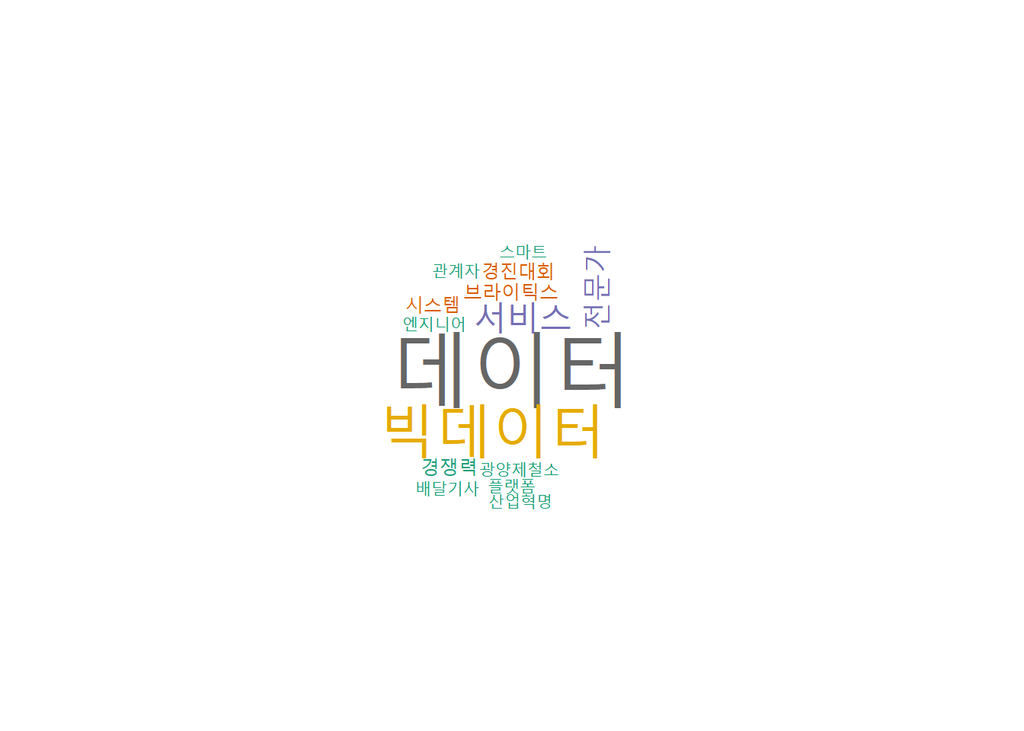

```r
wordcloud(words = names(term.freq),        # term.freq의 이름만 가져옴.
          freq = term.freq,                # 빈도는 위에 저장한 term.freq.
          min.freq = 5,                    # 최소빈도는 5
          random.order = F,
          colors = brewer.pal(8,'Dark2'))
```